#mengjie xu #assignment 3 In this assignment we will be applying the K-means clustering algorithm we looked at in class. At the following link you can find a description of K-means:

https://www.cs.uic.edu/~wilkinson/Applets/cluster.html

```r
#install.packages("ClusterR")
library(ClusterR)
library(dplyr)
library(tidyr)
```

Now, upload the file “Class_Motivation.csv” from the Assignment 3 Repository as a data frame called “K1”"

```r
K1 <- read.csv("Class_Motivation.csv")
```

This file contains the self-reported motivation scores for a class over five weeks. We are going to look for patterns in motivation over this time and sort people into clusters based on those patterns.

But before we do that, we will need to manipulate the data frame into a structure that can be analyzed by our clustering algorithm.

The algorithm will treat each row as a value belonging to a person, so we need to remove the id variable.

```r
K2 <- select(K1, -c("id"))
```

It is important to think about the meaning of missing values when clustering. We could treat them as having meaning or we could remove those people who have them. Neither option is ideal. What problems do you foresee if we recode or remove these values? Write your answers below:

We will remove people with missing values for this assignment, but keep in mind the issues that you have identified.

```r
K3 <- na.omit(K2) #This command create a data frame with only those people with no missing values. It "omits" all rows with missing values, also known as a "listwise deletion". EG - It runs down the list deleting rows as it goes.
```

Another pre-processing step used in K-means is to standardize the values so that they have the same range. We do this because we want to treat each week as equally important - if we do not standardise then the week with the largest range will have the greatest impact on which clusters are formed. We standardise the values by using the “scale()” command.

```r
K3 <- scale(K3)
```

Now we will run the K-means clustering algorithm we talked about in class. 1) The algorithm starts by randomly choosing some starting values 2) Associates all observations near to those values with them 3) Calculates the mean of those clusters of values 4) Selects the observation closest to the mean of the cluster 5) Re-associates all observations closest to this observation 6) Continues this process until the clusters are no longer changing

Notice that in this case we have 5 variables and in class we only had 2. It is impossible to vizualise this process with 5 variables.

Also, we need to choose the number of clusters we think are in the data. We will start with 2.

```r
fit <- kmeans(K3, 2)

#We have created an object called "fit" that contains all the details of our clustering including which observations belong to each cluster.

#We can access the list of clusters by typing "fit$cluster", the top row corresponds to the original order the rows were in. Notice we have deleted some rows.



#We can also attach these clusters to the original dataframe by using the "data.frame" command to create a new data frame called K4.

K4 <- data.frame(K3, fit$cluster)

#Have a look at the K4 dataframe. Lets change the names of the variables to make it more convenient with the names() command.

names(K4) <- c("1", "2", "3", "4", "5", "cluster")
```

Now we need to visualize the clusters we have created. To do so we want to play with the structure of our data. What would be most useful would be if we could visualize average motivation by cluster, by week. To do this we will need to convert our data from wide to long format. Remember your old friends tidyr and dplyr!

First lets use tidyr to convert from wide to long format.

```r
K5 <- gather(K4, week, motivation, 1:5, factor_key=TRUE)
```

Now lets use dplyr to average our motivation values by week and by cluster.

```r
K6 <- K5%>%group_by( week,cluster)%>%summarise(mean=mean(motivation))%>%arrange(week, cluster)
```

Now it’s time to do some visualization:

https://www.cs.uic.edu/~wilkinson/TheGrammarOfGraphics/GOG.html

And you can see the range of available graphics in ggplot here:

http://ggplot2.tidyverse.org/reference/index.html

We are going to create a line plot similar to the one created in the school dropout paper we looked at in class (Bowers, 2010). It will have motivation on the Y-axis and weeks on the X-axis. To do this we will want our weeks variables to be treated as a number, but because it was created from a variable name it is currently being treated as a character variable. You can see this if you click on the arrow on the left of K6 in the Data pane. Week is designated by “chr”. To convert it to numeric, we use the as.numeric command.

Likewise, since “cluster” is not numeric but rather a categorical label we want to convert it from an “integer” format to a “factor” format so that ggplot does not treat it as a number. We can do this with the as.factor() command.

```r
K6$week <- as.numeric(K6$week)
K6$cluster <- as.factor(K6$cluster)
```

Now we can plot our line plot using the ggplot command, “ggplot()”.

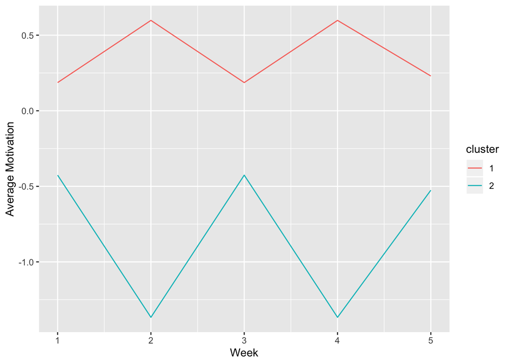

```r
library(ggplot2)
ggplot(K6, aes(week, mean, color = cluster)) +
  geom_line() +
  xlab("Week") +
  ylab("Average Motivation")
```

What patterns do you see in the plot?

It would be useful to determine how many people are in each cluster. We can do this easily with dplyr.

```r
K7<-dplyr::count(K4, cluster)
```

Look at the number of people in each cluster, now repeat this process for 3 rather than 2 clusters. Which cluster grouping do you think is more informative? Write your answer below:

```r
#Repeated the process for 3
K12 <- read.csv("Class_Motivation.csv")
K22 <- select(K12, -c("id"))
K32 <- na.omit(K22)
K32 <- scale(K32)
fit12 <- kmeans(K32, 3)
K42 <- data.frame(K32, fit12$cluster)
names(K42) <- c("1", "2", "3", "4", "5", "cluster")
K52 <- gather(K42, week, motivation, 1:5, factor_key=TRUE)
K52
```

```
##     cluster week motivation
## 1         1    1  1.0440258
## 2         2    1 -0.6711594
## 3         1    1  1.0440258
## 4         1    1  1.0440258
## 5         3    1  1.0440258
## 6         1    1  1.0440258
## 7         3    1 -0.6711594
## 8         3    1 -0.6711594
## 9         3    1 -0.6711594
## 10        3    1 -0.6711594
## 11        1    1  2.7592111
## 12        1    1  1.0440258
## 13        3    1 -0.6711594
## 14        2    1 -0.6711594
```

[output cut: 101 more lines]

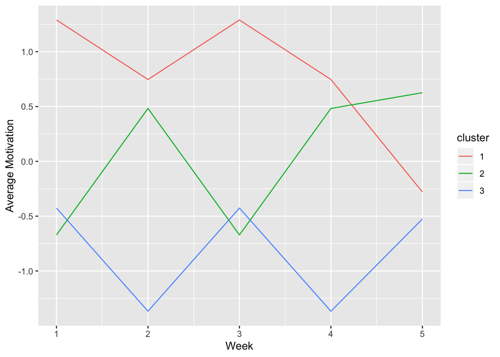

```r
K62 <- K52%>%group_by( week,cluster)%>%summarise(mean=mean(motivation))%>%arrange(week, cluster)
K62$week <- as.numeric(K62$week)
K62$cluster <- as.factor(K62$cluster)
ggplot(K62, aes(week, mean, color = cluster)) +geom_line() +
  xlab("Week") +
  ylab("Average Motivation")
```

```r
K72 <- dplyr::count(K42, cluster)
```

##Part II

Using the data collected for Assignment 2 (which classes students were in), cluster the students, then redraw the graph of the class but color the students according the cluster they are in.

```r
library(readr)
library(dplyr)
library(tidyr)
library(igraph)
#import data from the previous assignment
#Also refine the data to our desired form
D1 <- read.csv("hudk4050-classes.csv", header = TRUE, na.strings = "")
D1
```

```
##      First.Name Last.Name    Class.1     Class.2     Class.3     Class.4
## 1       Artemas      Wang  HUDK 4050   HUDK 4052   HUDM 5026        <NA>
## 2         Yawei       Zhu  HUDK 4050   HUDK 4052   HUDK 5053        <NA>
## 3       Ningyao        Xu  HUDK 4050   HUDM 4125   HUDM 5126   HUDM 5026
## 4        Qiyang       Lin  HUDK 4050   HUDM 4122   HUDK 4029   HUDK 4080
## 5       Bernell    Downer  HUDK 4050   HUDK 4052   HUDM 5126 QMSS GR5067
## 6         Ruiqi      Wang   HUDM4125    HUDM5026    HUDM5126    A&HA4063
## 7      Leonardo  Restrepo  HUDM 5122   HUDM 5026   HUDK 4052   HUDK 4050
## 8      Zhaozhuo     Zheng   HUDK4050    HUDK4052    HUDM4122    HUDM4120
## 9     Jiancong       Shen  HUDK 4052   HUDK 4050   HUDK 4029   HUDM 4050
## 10        ZIFAN       CAO   HUDK4050        <NA>        <NA>        <NA>
## 11      Allison    Teevan  HUDK 4050        <NA>        <NA>        <NA>
## 12        Yiwen        Ma  HUDK 4050   HUDM 5026   HUDM 5126   HUDM 4125
## 13       Beibei       Cao  HUDK 4050   EDPE 6151   EDPE 4155   EDPA 4047
## 14       yixiao        li   HUDK4050 IFSF4090002 EDPS4002001 EDPS4021001
```

[output cut: 93 more lines]

```r
D2 <- unite(D1, "First.Name", "Last.Name", col = name, sep = "_")
D3 <- D2 %>% gather(classnum, classcode, `Class.1`, `Class.2`, `Class.3`, `Class.4`, `Class.5`, `Class.6`) %>% select(-c(classnum))
D3$classcode = gsub(" ", "", D3$classcode)
D3 <- D3 %>% filter(classcode != "HUDK4050") %>% filter(name != "ZIMO_CHEN")
D3$Count = 1
D4 <- D3 %>% spread(classcode,Count)
row.names(D4) = D4$name
D4$name <- NULL
D4 = ifelse(is.na(D4), 0, 1)
D5 = as.matrix(D4)
```

Cluster

```r
fit2 <- kmeans(D5, 4)
fit2$cluster
```

```
##   Alysandra_Zhang         Anqi_Duan      Artemas_Wang        Beibei_Cao
##                 2                 3                 3                 2
##    Bernell_Downer    chaoxiong_chen      Chengxuan_Hu        Chenyu_Yan
##                 3                 1                 4                 3
## Christine_Odenath      David_Pearce            Di_Mao  Eudora Xinyi_Niu
##                 2                 1                 4                 2
##            HAN_GE          Han_Wang   INDIRA_BATAYEVA        jiahao_guo
##                 1                 2                 1                 4
##    Jiancong _Shen          Jie_Chen      Jingru_Zhang      Joellyn_Heng
##                 1                 1                 4                 2
## Leonardo_Restrepo           Ling_Ai     LINGLING_MIAO        Lintong_Li
##                 3                 2                 4                 1
##          Luyi_Dai      Maho_Hayashi       Minruo_Wang        Ningyao_Xu
##                 4                 2                 2                 4
##        Qiyang_Lin        Ruiqi_Wang      Shijie _Shao       Suwon _Jung
##                 1                 4                 4                 1
##       Timothy_Lee      Wanruo_Zhang           XI_YANG      Xiaowen_Chen
##                 3                 1                 4                 1
##        xinyi_zhou      XUDIAN_ZHANG           YAQI_LU         Yawei_Zhu
##                 3                 4                 2                 3
##         Yigao_Liu          Yiwei_Qi          Yiwen_Ma         yixiao_li
##                 2                 2                 4                 2
##        Yixuan_Zhu          Yiyi_Xie       Yujun_Zhang    Zhaozhuo_Zheng
##                 1                 3                 3                 3
##   Zhongyuan_Zhang        Ziyuan_Guo
##                 3                 4
```

```r
D6 <- data.frame(D5, fit2$cluster)
colnames(D6)[colnames(D6)=="fit2.cluster"] <- "cluster"
Count <- dplyr::count(D6, cluster)
Count
```

```
## # A tibble: 4 x 2
##   cluster     n
##     <int> <int>
## 1       1    12
## 2       2    13
## 3       3    12
## 4       4    13
```

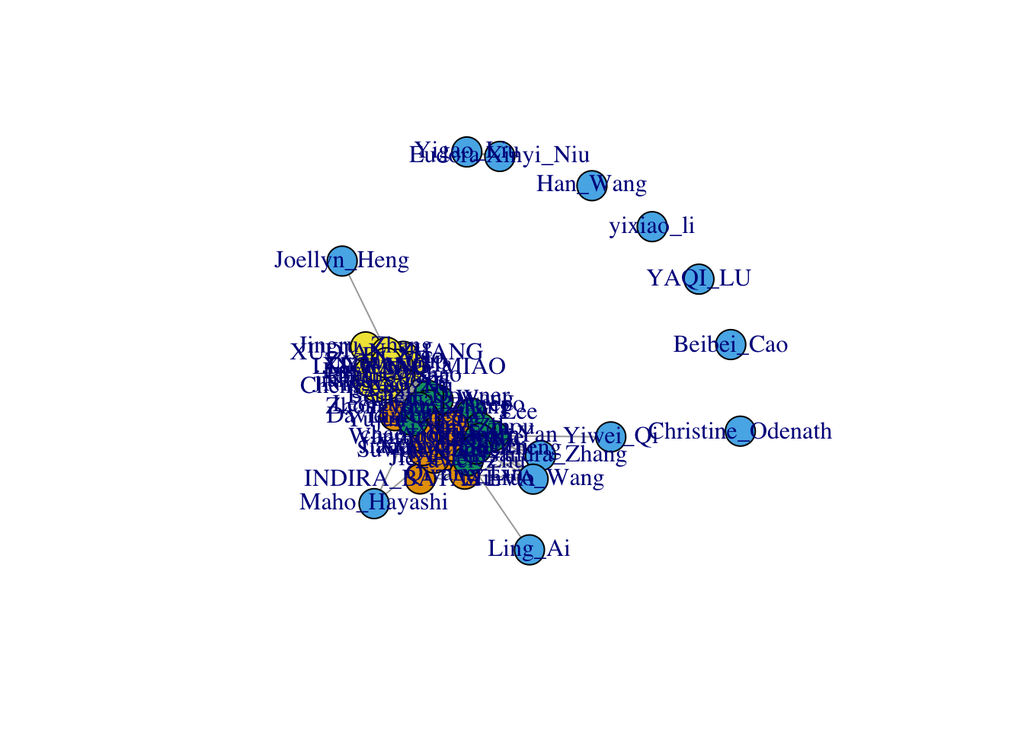

```r
D7 = D5 %*% t(D5)
diag(D7) <- NA
library(igraph)
g3 = graph.adjacency(D7, mode = "undirected")
plot(g3, layout=layout.fruchterman.reingold, vertex.color=D6$cluster)
```

##Part III

In class activity 6 you clustered students in the class by the answers to a questionaire. Create a visualization that shows the overlap between these clusters and the clusters generated in part II.

```r
F1 <- read.csv("HUDK405019-clustering.csv", header = TRUE)
F1[, 3] <- gsub("[[:alpha:]]", "", F1[, 3])
F1[, 6] <- gsub("[[:alpha:]]", "", F1[, 6])
F1[, 7] <- gsub("[[:alpha:]]", "", F1[, 7])
F1[, 3] <- as.numeric(F1[, 3])
F1[, 6] <- as.numeric(F1[, 6])
F1[, 7] <- as.numeric(F1[, 7])
F1[, 15] <- as.character(F1[, 15])
F1[, 16] <- as.character(F1[, 16])
rev <- grep("E", F1[, 15])
a <- NULL
b <- NULL
for (i in rev) {
  a = F1[i, 15]
  b = F1[i, 16]
  F1[i, 15] <- b
  F1[i, 16] <- a
}
for (j in c(15:16)){
  for (i in 1:nrow(F1))
  { if (grepl("\\D", F1[i,j]))
  { psn <- as.numeric(regexpr("\\D", F1[i,j]))
    F1[i,j] <- substr(F1[i,j], 1, psn-1)}}
}
F1[, 15] <- as.numeric(F1[, 15])
F1[, 16] <- as.numeric(F1[, 16])
F1 <- na.omit(F1)
F1[, 15] <- as.character(F1[, 15])
F1[, 16] <- as.character(F1[, 16])
F2 <- unite(F1, "First.Name", "Last.Name", col = name, sep = "_")
row.names(F2) = F2$name
F2$name <- NULL
select_if(F2, is.numeric)
```

[output not shown]

[output cut: 365 more lines]

[output not shown]

```r
names(select_if(F2, is.numeric))
```

```
##  [1] "How.many.months.have.you.lived.in.New.York.City."
##  [2] "How.many.siblings..brothers.sisters..do.you.have."
##  [3] "How.many.times.do.you.play.sport.each.week."
##  [4] "How.many.miles.do.you.travel.from.home.to.TC."
##  [5] "Estimate.how.many.of.your.friends.own.Android.phones"
##  [6] "How.many.movies.have.you.seen.in.the.cinema.this.year."
##  [7] "How.many.pets.have.you.owned.in.your.life."
##  [8] "How.many.people.have.you.met.for.the.first.time.this.year."
##  [9] "How.many.time.do.you.cook.for.yourself.each.week."
## [10] "How.many.classes.are.you.taking.this.semester."
```

```r
F3 <- select(F2, "How.many.months.have.you.lived.in.New.York.City.", "How.many.siblings..brothers.sisters..do.you.have.",  "How.many.times.do.you.play.sport.each.week.", "How.many.miles.do.you.travel.from.home.to.TC.", "Estimate.how.many.of.your.friends.own.Android.phones",  "How.many.movies.have.you.seen.in.the.cinema.this.year.", "How.many.pets.have.you.owned.in.your.life.",  "How.many.people.have.you.met.for.the.first.time.this.year.",   "How.many.time.do.you.cook.for.yourself.each.week.", "How.many.classes.are.you.taking.this.semester.")
F3 <- scale(F3)
fit3 <- kmeans(F3, 4)
fit3$cluster
```

```
##      Artemas_Wang       Timothy_Lee        jiahao_guo Leonardo_Restrepo
##                 3                 4                 2                 3
##        Xinke_Song        Zixuan _Ma          Yiwei_Qi        XINYI_ZHOU
##                 2                 2                 1                 2
##       XIAOJUE_LIU      Minruo _Wang         Anqi_Duan      Chengxuan_Hu
##                 2                 4                 4                 2
##    CHAOXIONG_CHEN           Ling_Ai      Joellyn_Heng       Ruiqi _Wang
##                 3                 4                 2                 2
##          BOZI_JIN        Qiyang_Lin          Yiyi_Xie          Yiwen_Ma
##                 1                 2                 1                 2
##        Ziyuan_Guo       Shijie_Shao        Eudora_Niu     Jiancong_Shen
##                 2                 2                 4                 2
##          Yijia_Wu           XI_YANG        Beibei_Cao        Chenyu_Yan
##                 2                 2                 2                 4
##     LINGLING_MIAO     Maho _Hayashi        Suwon_Jung      Xiaowen_Chen
##                 4                 3                 3                 2
##         Jiali_Jin        Lintong_Li        Ningyao_Xu   Zhongyuan_Zhang
##                 2                 2                 4                 2
##           Yaqi_Lu       Yujun_Zhang      Xudian_Zhang          Jie_Chen
##                 2                 1                 2                 2
##          Han_Wang
##                 1
```

```r
K34 <- data.frame(F3, fit3$cluster)
names(K34) <- c("1", "2", "3", "4", "5", "6", "7", "8", "9", "10", "cluster")
F4 <- data.frame(K34, F1[15])
F5 <- data.frame(F4, F1[16])
colnames(F5) <- c("1", "2", "3", "4", "5", "6", "7", "8", "9", "10", "cluster", "la", "lo")
F35 <- F5[row.names(F5) %in% row.names(D6), ]
D36 <- D6[row.names(D6) %in% row.names(F35), ]
F35$name <- rownames(F35)
D36$name <- rownames(D36)


library(vcd)
```

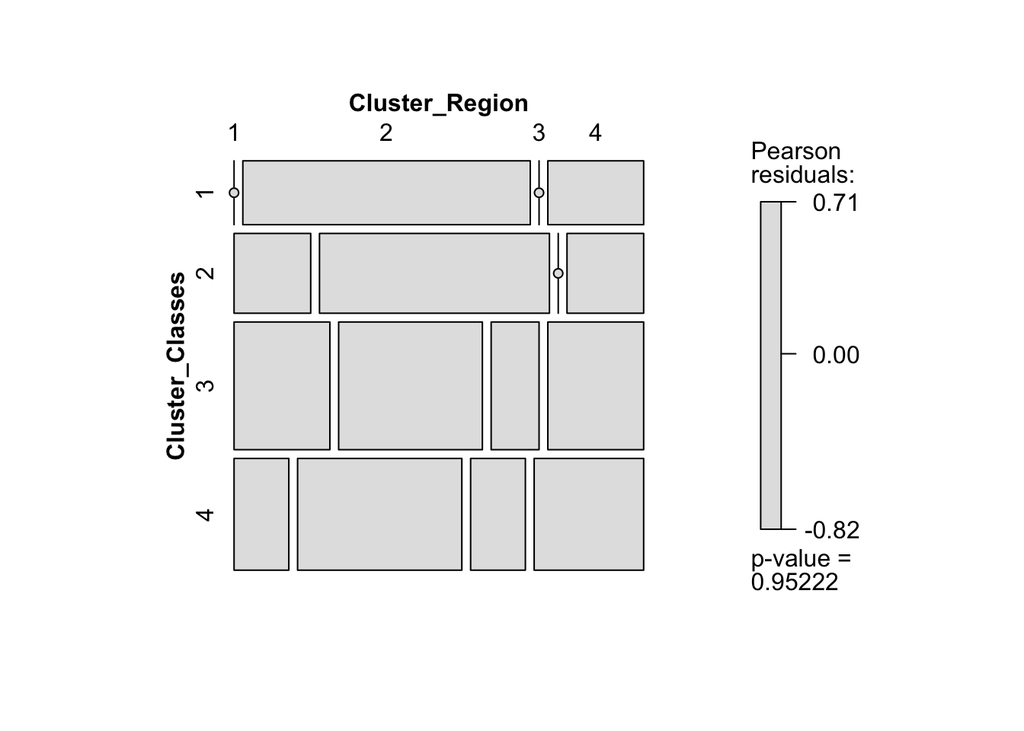

```r
Cluster_Region = F35$cluster
Cluster_Classes = D36$cluster
A1 <- structable(Cluster_Region ~ Cluster_Classes)
mosaic(A1, shade = TRUE, legend = TRUE)
```

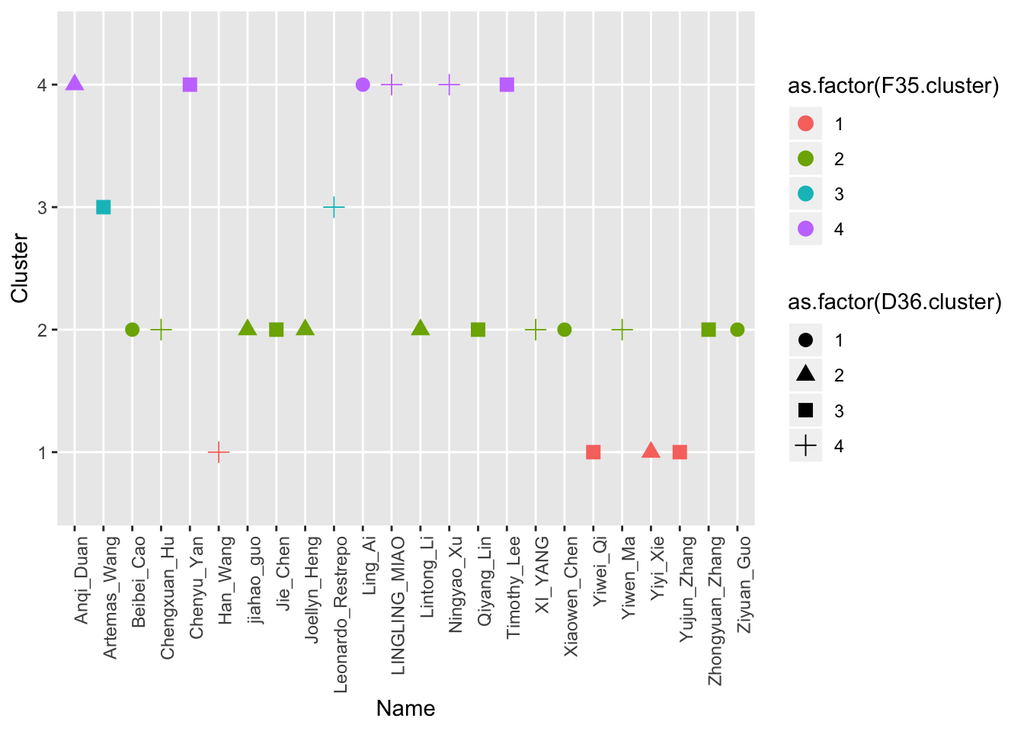

```r
B1 <- cbind(F35$cluster, D36$cluster, F35$name)
colnames(B1) = c("F35.cluster", "D36.cluster", "name")

B1 <- as.data.frame(B1)
ggplot(B1, aes(name, F35.cluster, color = as.factor(F35.cluster), shape = as.factor(D36.cluster))) +
  geom_point(size = 3) +
  xlab("Name") +
  ylab("Cluster") +
  theme(axis.text.x = element_text(angle = 90, hjust = 1))
```

## Please render your code as an .html file using knitr and Pull Resquest both your .Rmd file and .html files to the Assignment 3 repository.